# Deep Learning with Twitter Sentiment Analysis

# [TABLE OF CONTENTS]

0. Workspace Setup
1. Problem
2. Data
3. Technique
4. Refinement
5. Conclusions

# 0. WORKSPACE SETUP

Employ the use of several important packages, among them being *tidyverse* for data cleaning, *keras* for deep learning, and *rtweet and twitteR* for accessing Twitter’s api. The steps to authenticate and access Twitter are shown below:

### load relevant libraries

```r
library(caret)
library(tidyverse)
library(skimr)
library(plyr)
library(data.table)
library(bit64)
library(keras)
# install.packages('rtweet')
library(rtweet)
# install.packages('twitteR')
library(twitteR)
library(ggridges)
```

### create api key variables

```r
## store api keys
api_key <- "XXXXXXXXXXXXXXXXXXXXXXXXXXXXXXX"
api_secret_key <- "XXXXXXXXXXXXXXXXXXXXXXXXXXXXXXX"
access_token <- "XXXXXXXXXXXXXXXXXXXXXXXXXXXXXXX"
access_token_secret <- "XXXXXXXXXXXXXXXXXXXXXXXXXXXXXXX"
```

### generate auth token & connect to twitter dev app

```r
## authenticate via access token
token <- create_token(
  app = "MyTwoSents",
  consumer_key = api_key,
  consumer_secret = api_secret_key,
  access_token = access_token,
  access_secret = access_token_secret)
```

### confirm successful authentication

```r
get_token()
```

# 1. PROBLEM

The problem at hand is **predicting how stocks will behave**, however, this isn’t always as clear as crunching spreadsheets of timeseries financial data. Often times people trade stocks based on experience, on privileged industry information, on their personal tolerane to risk, and even on gut intuition alone. Thus, this project takes an alternate approach at determining whether a stock is *good* or *bad* by using sentiment from tweets surrounding those stocks to assign a positive/negative score. From there, a deep learning model should, hypothetically, be able to classify stocks as positive or negative based on the sentiment scores learned from the training data. The methodology is below:

# 2. DATA

For the data aspect of this project, Twitter api is utilized to mine tweet data regarding four stock indices; **Crude Oil, Gold, NSE, and DOW**.

Limit the api call to hashtags related to these stocks, filter by tweets in english, filter again by time period (since august 2019), and opt not to include retweets to avoid duplicative text. Next, convert the resulting tweet lists to dataframes for easy manipulation and write them to csv files so the raw stock data can be accessed later, if needed. These steps are shown below:

### search & import tweets by hashtag

```r
crude_tweet <- search_tweets("#oil", n=20000, lang= "en", since='2019-08-01', until='2020-05-01', include_rts = FALSE)
gold_tweet <- search_tweets("#gold", n=20000, lang= "en", since='2019-08-01', until='2020-05-01', include_rts = FALSE)
nse_tweet <- search_tweets("#nse", n=20000, lang= "en", since='2019-08-01', until='2020-05-01', include_rts = FALSE)
dow_tweet <- search_tweets("#djia", n=20000, lang= "en", since='2019-08-01', until='2020-05-01', include_rts = FALSE)
```

### convert tweet lists to dataframes

```r
crude_tweet <- twListToDF(crude_tweet)
gold_tweet <- twListToDF(gold_tweet)
nse_tweet <- twListToDF(nse_tweet)
dow_tweet <- twListToDF(dow_tweet)
```

### write tweet data to csv files in case of future need

```r
write.csv(crude_tweet,"crude_tweet.csv")
write.csv(gold_tweet,"gold_tweet.csv")
write.csv(nse_tweet,"nse_tweet.csv")
write.csv(dow_tweet,"dow_tweet.csv")
```

Now, create a function that will complete the following steps: 1. Receive tweet text as input 2. Remove sentence pattern, split by word and unlist them 3. Compare words to positive/negative indices 4. Sum positive words/ sum negative words in each tweet 5. Produce difference of positive vs. negative words 6. Score tweets based on that difference NOTE: this process will, by definition, determine the *sentiment* of each tweet. The sentiment scores can, and will, go on to be used as labels for the training data which will fuel the learning of the deep learning model.

### select text column from tweet sets

```r
crude_text  <- crude_tweet$text
gold_text  <- gold_tweet$text
nse_text  <- nse_tweet$text
dow_text <- dow_tweet$text
```

### load positive/negative words indices

```r
positive_word = readLines("positive-words.txt")

negative_word = readLines("negative-words.txt")
```

Note: above are lists of english words determined to have positive or negative sentiment that were downloaded from the internet

### create tweet-processing function

```r
# define function
score_sentiment = function(sentences, positive_word, negative_word,.progress='none')
{
  scores = laply(sentences, function(sentence, positive_word, negative_word) {

    # format sentences to remove pattern
    sentence = gsub('[[:punct:]]', '', sentence)

    sentence = gsub('[[:cntrl:]]', '', sentence)

    sentence = gsub('\\d+', '', sentence)

    # convert all sentence to lower case
    sentence = tolower(sentence)

    # split sentences into individual words
    word_list = str_split(sentence, '\\s+')

    # unlist words
    words = unlist(word_list)

    # compare tweet words to positive/negative indices
    positive_matches = match(words, positive_word)

    negative_matches = match(words, negative_word)

    # determine, by logical TRUE/FALSE. whether tweet words are pos or neg
    # and exclude NA values
    positive_matches = !is.na(positive_matches)

    negative_matches = !is.na(negative_matches)

    # sum and take difference of pos vs. neg
    score = sum(positive_matches) - sum(negative_matches)

    # return the score of each tweet
    return(score)

  }, positive_word, negative_word, .progress=.progress)

  scores.df = data.frame(score=scores, text=sentences)

  return(scores.df)

}
```

Next, apply the scoring function to each of the four tweet lists and visualize the raw distribution of score by commodity just to gain some overview of the data.

### apply score function and visualize

```r
crude_score = score_sentiment(crude_text,positive_word,negative_word,.progress='text')
gold_score = score_sentiment(gold_text,positive_word,negative_word,.progress='text')
nse_score = score_sentiment(nse_text,positive_word,negative_word,.progress='text')
dow_score = score_sentiment(dow_text,positive_word,negative_word,.progress='text')
```

Finally, add commodity names and code assignments to the tweet lists, combine and save them as one master dataset of all four stocks.

### combine and save

[figure not shown]

```r
# add commodity name column
crude_score$commodity = "Crude"
gold_score$commodity = "Gold"
nse_score$commodity = "Nse"
dow_score$commodity = "Dow"

# add commodity code column
crude_score$code = "WTI"
gold_score$code = "AUX"
nse_score$code = "Nse"
dow_score$code = "Dow"

tot_data <- rbind(nse_score,dow_score,crude_score,gold_score)

write.csv(tot_data,"tot_data.csv")
```

# 3. TECHNIQUE

A discussion of technique is necessary at this point as there are many considerations surrounding natural language processing. How do you treat abbreviated words? Is preserving sentence order worth the extra computational expenditure? What deep learning model is best suited for text sentiment? These, and many more, are the questions asked during this phase of the project. Let’s began by attempting work with a convolutional network, building covnet layers into the model to classify the score of each tweet. Covnets are most commonly used for image classification, and there was difficulty getting it to pickup sentiment information from the feature space (containing tweet words) like it would otherwise pick up patterns from a feature space containing the pixels in a photo. The results of this were underwhelming; opted to build the base model as a keras sequential model with a dense layer.

Though, before building the model the master tweet dataset was first filtered to only scores of **-2 (very bad), -1 (bad), 1 (good), and 2 (very good). Given the histogram view of the data, there weren’t many scores at the extremes (scores >= 3 or <= -3) which prompted a re-adjustment of the scoring scale. Then pick a random sample of 23,000 tweets for training and 2,000 for testing. Finally, look at a visualization of the newly score-filtered data. Steps below:

### filter by score, then sample

```r
tot_data <- read_csv("tot_data.csv")
data <- tot_data %>% filter( score>-3 & score <3 & score !=0) #

train_data <- sample_n(data,23000)

test_data <- sample_n(data,2000)
```

### visualize filtered data

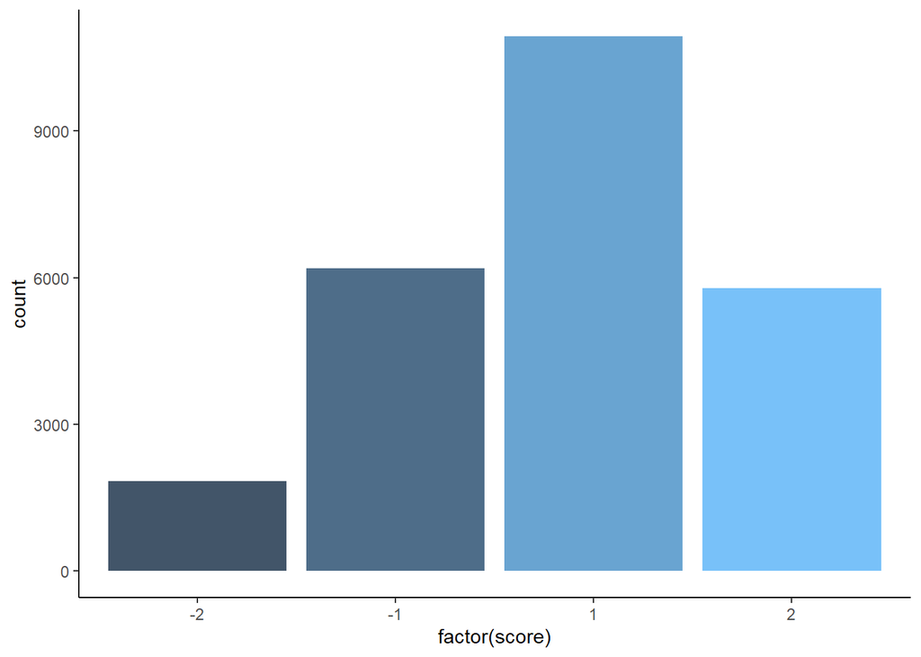

```r
ggplot(data,aes(x = factor(score), fill = score)) +
  geom_bar(alpha = 0.8) +
  guides(fill = FALSE)+ theme_classic()
```

Next, tokenize the data; a necessary step for this deep learning model to be successful. Below, the script converts the text of each tweet to a series of integers assigned to each distinct word. Then, it assigns the text tokenizer a maximum amount of features to consider (in this case, the top 100 most frequent). Finally, it fits the tokenizer to the data. Steps below:

### tokenize and fit

```r
text_train <- train_data$text
text_test <- test_data$text

max_features <- 100
tokenizer <- text_tokenizer(num_words = max_features)

tokenizer %>%
  fit_text_tokenizer(text_train)

# ouptut top 3 words from index for confirmation
tokenizer$word_index %>% head(3)
```

```
## $u
## [1] 1
##
## $`0085`
## [1] 2
##
## $`\r\r`
## [1] 3
```

Now, using the word index developed by the tokenizer, convert the tweet text in both sets to integer sequences. These sequences aren’t quite enough for the model to understand, however. Thus, on-hot encoding methods are used to further convert the integer values in each sequence to binary integer vectors that possess a 1 for the index of an integer and zeros for all else. Repeat this one-hot encoding process for the *labels* of the data as well; these labels will be how the model determines how to classify tweets in the test set. Steps below:

### sequence conversion and encoding

```r
sequences <- texts_to_sequences(tokenizer, text_train)
sequences_2 <- texts_to_sequences(tokenizer, text_test)

one_hot_train_text <- sequences_to_matrix(tokenizer, sequences, mode = "binary")
one_hot_test_text <- sequences_to_matrix(tokenizer, sequences_2, mode = "binary")
```

### encoding of labels

```r
train_labels <- train_data$score
test_labels <- test_data$score
to_one_hot <- function(labels, dimension = 4) {
results <- matrix(0, nrow = length(labels), ncol = dimension)
for (i in 1:length(labels))
results[i, labels[[i]]] <- 1
results
}
one_hot_train_labels <- to_one_hot(train_labels)
one_hot_test_labels <- to_one_hot(test_labels)
```

Finally, build the basic sequential model with a dense layer and plot the results to determine how the epoch levels should be readjusted. Below, the model is built, compiled, and fitted with a 30% split for validation data:

### base model (dense-layer)

```r
set.seed(0)
model <- keras_model_sequential() %>%
layer_dense(units = 64, activation = "relu", input_shape = c(100)) %>%
layer_dense(units = 64, activation = "relu") %>%
layer_dense(units = 4, activation = "softmax")

summary(model)
```

```
## Model: "sequential"
## ________________________________________________________________________________
## Layer (type)                        Output Shape                    Param #
## ================================================================================
## dense (Dense)                       (None, 64)                      6464
## ________________________________________________________________________________
## dense_1 (Dense)                     (None, 64)                      4160
## ________________________________________________________________________________
## dense_2 (Dense)                     (None, 4)                       260
## ================================================================================
## Total params: 10,884
## Trainable params: 10,884
## Non-trainable params: 0
## ________________________________________________________________________________
```

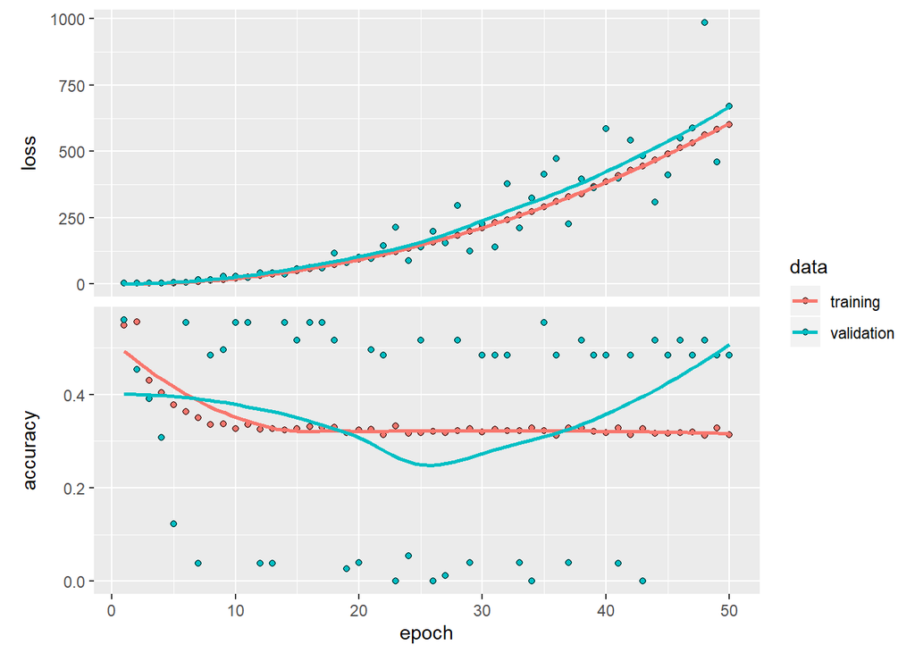

```r
model %>% compile(
optimizer = "rmsprop",
loss = "categorical_crossentropy",
metrics = c("accuracy"))

history <- model %>% fit(
  one_hot_train_text,
  one_hot_train_labels,
  epochs = 50,
  batch_size = 200,
  validation_split = 0.3
  )

plot(history)
```

### re-train base model

```r
model %>% fit(
  one_hot_train_text,
  one_hot_train_labels,
  epochs = 2,
  batch_size = 200,
  )
```

### predict on test

```r
predictions <- model %>% predict(one_hot_test_text)

# Each entry in predictions is a vector of length 4
dim(predictions)
```

```
## [1] 2000    4
```

```r
# The coefficients in this vector sum to 1:
sum(predictions[1,])
```

```
## [1] 1
```

```r
# The largest entry is the predicted class—the class with the highest probability:
which.max(predictions[500,])
```

```
## [1] 2
```

### evaluate base model

```r
(eval_dense <- model %>% evaluate(one_hot_test_text,one_hot_test_labels))
```

```
## $loss
## [1] 730.3832
##
## $accuracy
## [1] 0.479
```

# 4. REFINEMENT

To refine and improve our model, two methods are used that are well-suited for NLP. The first tried is adding an RNN layer. Because the model is recurrent, it’ll (hopefully) gain important sentiment information from the sequences of integers in the encoded tweet text. It holds the feature space constant at the top 100 most frequent words and cuts the length of a tweet off after 20 words. Use categorical crossentropy as the loss property because the objective is a multiclassification problem (-2, -1, 1, 2) and complete the output layer with softmax activation. The resulting output will be a four-dimensional vector that is trained to get as close to a ‘correct’ label as possible based on probability. RNN steps are below:

### basic RNN model

```r
# Number of words to consider as features
max_features <- 100

# Cuts off texts after this many words (among the max_features most commonwords)
maxlen <- 20

# Turns the lists of integers into a 2D integer tensor of shape (samples, maxlen)
one_hot_train_text <- pad_sequences(one_hot_train_text, maxlen = maxlen)
one_hot_test_text <- pad_sequences(one_hot_test_text, maxlen = maxlen)

model <- keras_model_sequential() %>%
layer_embedding(input_dim = max_features, output_dim = 4,input_length = maxlen) %>%
layer_simple_rnn(units = 32) %>%
layer_dense(units = 4, activation = "softmax")

summary(model)
```

```
## Model: "sequential_1"
## ________________________________________________________________________________
## Layer (type)                        Output Shape                    Param #
## ================================================================================
## embedding (Embedding)               (None, 20, 4)                   400
## ________________________________________________________________________________
## simple_rnn (SimpleRNN)              (None, 32)                      1184
## ________________________________________________________________________________
## dense_3 (Dense)                     (None, 4)                       132
## ================================================================================
## Total params: 1,716
## Trainable params: 1,716
## Non-trainable params: 0
## ________________________________________________________________________________
```

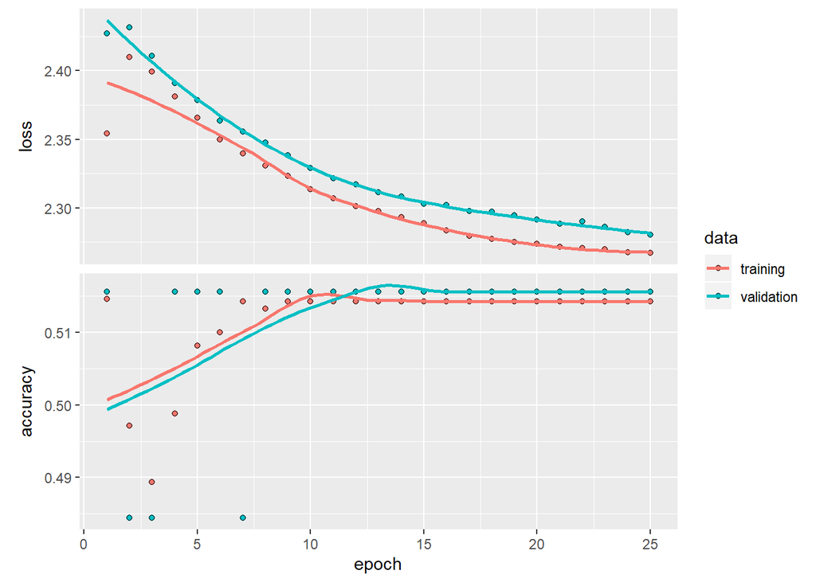

```r
model %>% compile(
optimizer = "rmsprop",
loss = "categorical_crossentropy",
metrics = c("accuracy"))


history <- model %>% fit(
one_hot_train_text,
one_hot_train_labels,
epochs = 25,
batch_size = 200,
validation_split = 0.3
)

plot(history)
```

### re-train RNN at 16 epochs

```r
model %>% fit(
one_hot_train_text,
one_hot_train_labels,
epochs = 16,
batch_size = 200)
```

### evaluate RNN

```r
(eval_rnn <- model %>% evaluate(one_hot_test_text,one_hot_test_labels))
```

```
## $loss
## [1] 2.279579
##
## $accuracy
## [1] 0.521
```

One final refinement attempted is the use of long short-term memory in our deep learning network. LSTM is best suited for timeseries data as it can process and glean information from whole sequences at once through feedback connections. This will (hopefully) help the model gain sentiment information from the encoded tweet sequences. Much of the model is now held constant; add an lstm layer below:

### LSTM model - further refinement

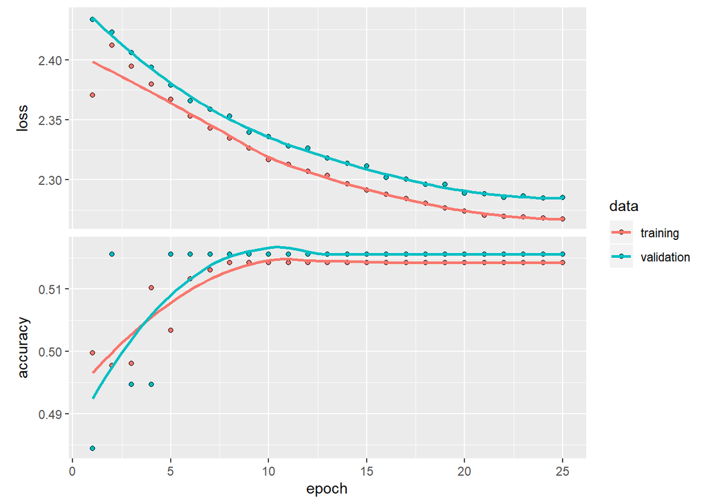

```r
model_lstm <- keras_model_sequential() %>%
layer_embedding(input_dim = max_features, output_dim = 32) %>%
layer_lstm(units = 32) %>%
layer_dense(units = 4, activation = "softmax")

model_lstm %>% compile(
optimizer = "rmsprop",
loss = "categorical_crossentropy",
metrics = c("accuracy"))


history_lstm <- model_lstm %>% fit(
one_hot_train_text,
one_hot_train_labels,
epochs = 25,
batch_size = 200,
validation_split = 0.3
)

plot(history_lstm)
```

### re-train LSTM with 15 epochs

```r
model_lstm %>% fit(
one_hot_train_text,
one_hot_train_labels,
epochs = 15,
batch_size = 200)
```

### evaluate LSTM

```r
(eval_lstm <- model_lstm %>% evaluate(one_hot_test_text,one_hot_test_labels))
```

```
## $loss
## [1] 2.280023
##
## $accuracy
## [1] 0.521
```

# 5. CONCLUSIONS

Although our results are not ideal, they would be an important step on the way to improving a useable deep learning model in the real-world. Regarding the results, some limitations proved a detriment to the success of this model, mainly computational power related. Without connection to a paid cloud server, the model was forced to keep the train sample sizes small. Having millions more stock tweets scored by sentiment to learn from would give this model a more robust ability to classify the test data. Further, the success of these RNN techniques implemented hinge on the idea of preserving tweet text *order* to gain vital sentiment information from the wording of tweets and not just the individual words themselves. An example of this would be using the word *crazy*, which would otherwise be negative by itself, to indicate that someone was amazing at a certain sport. This lingo usage is often the case with natural language and can drastically impact the meaning of a tweet. However, preserving and feeding this sequential text back through the model proves computationally expensive and so the model was opted to lax on order preservation a bit to run the model more efficiently; a safely determined compromise as tweets about stocks seem more direct to the point than, say, a more verbose movie review would be. Finally, aspects of the model could change like the maximum feature space and length of each tweet. Maybe it could include the top 100,000 most frequent english words in the feature space and provide *no limit* to the length of each tweet, which would provide the training model vastly more information to learn from.